# Problem Set 4 - Gapminder

## Introduction

This assignment is part of problem set 4 of the “Data Analysis with R” Udacity course’s lesson 4: “Explore Two Variable”.  
The task is to go back to the Gapminder dataset used in problem set 3 and study it with tools from lesson 4.

### The Dataset

The dataset chosen from Gapminder is a subset of a larger dataset of “the average number of years of school attended by all people in the age and gender group specified, including primary, secondary and tertiary education”. The subset concerned only women between the age of 25-34. The source of the data is the Institute for Health Metrics and Evaluation and it was uploaded in 2010.

[Gapminder - Mean years in school (women 25-34)](https://spreadsheets.google.com/spreadsheet/pub?key=0ArfEDsV3bBwCdC1MYzAtY2xPQ2xOR1lMeGhYSWlpR0E&gid=0)

## Dataset Investigation and Observations

This chapter shows the tools and code used in the investigation of the dataset, as well as the observations and notes taken along the study.

### Data Wrangling

From lesson 3:

```r
school.years <- read.csv("Years.in.school.women.25-34.csv", header = TRUE, check.names = FALSE)
library(tidyr)
suppressMessages(library(dplyr))
suppressMessages(library(ggplot2))

names(school.years)[1] <- "country"
gather.school <- gather(data = school.years, key = "year", value = "mean.num.years",
    2:length(school.years))
```

### Scatter Plot

Scatter plot of the data with the values for median and quantiles 10% and 90%, in blue.

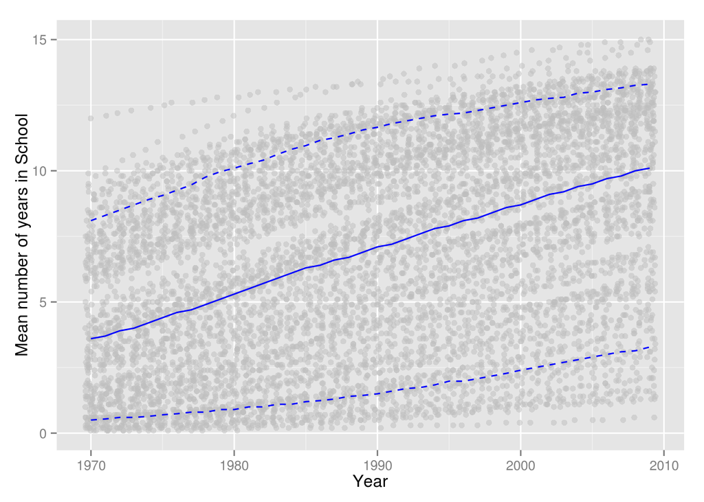

```r
gather.school <-
  gather.school %>%
  mutate(year.as.numeric = as.numeric(year))

ggplot(aes(x = 1969 + year.as.numeric, y = mean.num.years), data = gather.school) +
  geom_point(alpha = 1/2, position = position_jitter(h=0), color = 'grey') +
  geom_line(stat = 'summary', fun.y = median, color = 'blue') +
  geom_line(stat = 'summary', fun.y = quantile, probs = .9 , color = 'blue', linetype = 2) +
  geom_line(stat = 'summary', fun.y = quantile, probs = .1 , color = 'blue', linetype = 2) +
  ylab("Mean number of years in School") +
  xlab("Year")
```

### Portugal and neighbors

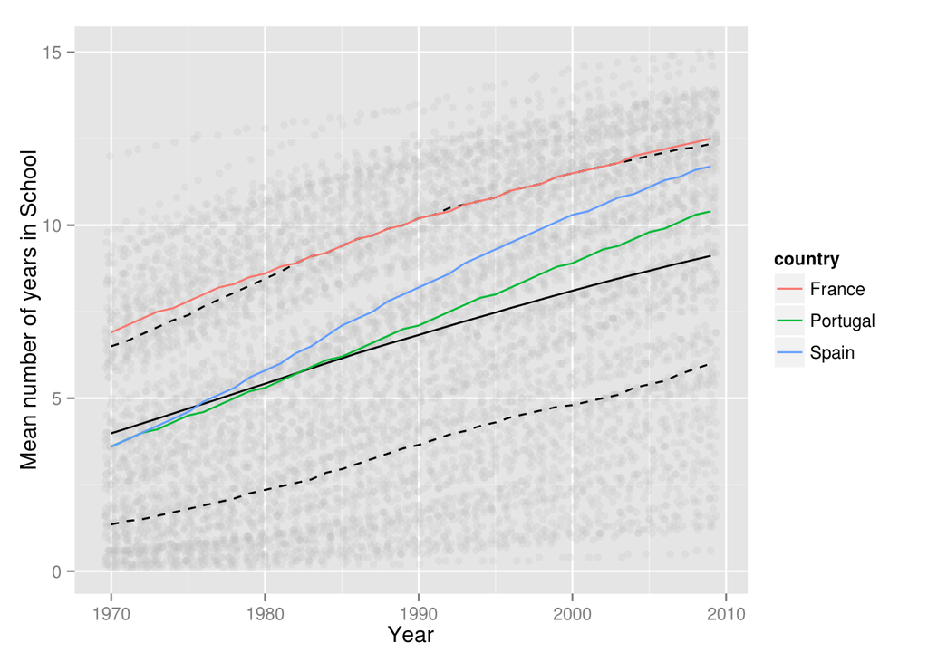

```r
ggplot(aes(x = 1969 + year.as.numeric, y = mean.num.years), data = gather.school) +
  geom_point(alpha = 1/5, position = position_jitter(h=0), color = 'grey') +
  geom_line(stat = 'summary', fun.y = mean) +
  geom_line(stat = 'summary', fun.y = quantile, probs = .75 , linetype = 2) +
  geom_line(stat = 'summary', fun.y = quantile, probs = .25 , linetype = 2) +
  geom_line(data = subset(gather.school, country %in% c("Portugal", "Spain", "France")), aes(color = country)) +
  ylab("Mean number of years in School") +
  xlab("Year")
```

### Countries with largest and smallest improvement

#### Countries with the largest improvement

Now we take a look at the countries which had the highest increase in mean number of years spent in school between the year of 1970 and 2009 (from problem set 3).

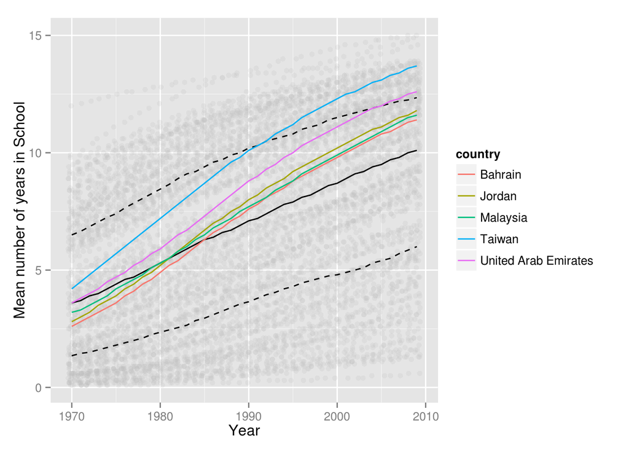

```r
ggplot(aes(x = 1969 + year.as.numeric, y = mean.num.years), data = gather.school) +
  geom_point(alpha = 1/5, position = position_jitter(h=0), color = 'grey') +
  geom_line(stat = 'summary', fun.y = median) +
  geom_line(stat = 'summary', fun.y = quantile, probs = .75 , linetype = 2) +
  geom_line(stat = 'summary', fun.y = quantile, probs = .25 , linetype = 2) +
  geom_line(data = subset(gather.school, country %in%
      c("Taiwan", "Jordan", "United Arab Emirates", "Bahrain","Malaysia")), aes(color = country)) +
  ylab("Mean number of years in School") +
  xlab("Year")
```

#### Countries with the smallest improvement

Next we take a look at the countries which had the smallest increase in mean number of years spent in school between the year of 1970 and 2009 (from problem set 3).

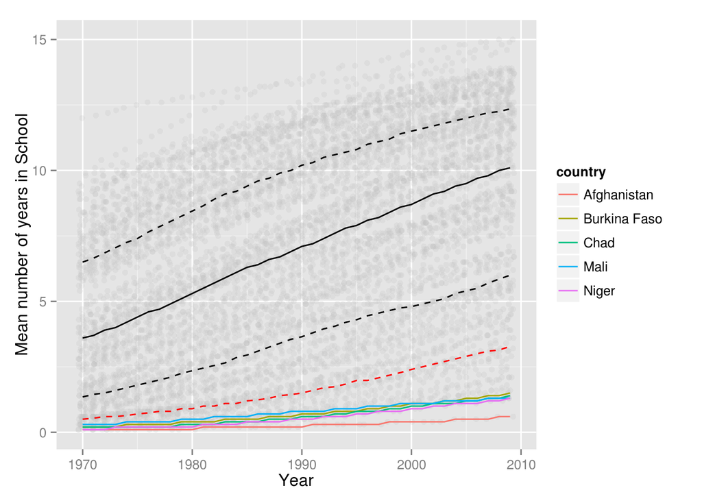

```r
ggplot(aes(x = 1969 + year.as.numeric, y = mean.num.years), data = gather.school) +
  geom_point(alpha = 1/5, position = position_jitter(h=0), color = 'grey') +
  geom_line(stat = 'summary', fun.y = median) +
  geom_line(stat = 'summary', fun.y = quantile, probs = .75 , linetype = 2) +
  geom_line(stat = 'summary', fun.y = quantile, probs = .25 , linetype = 2) +
  geom_line(stat = 'summary', fun.y = quantile, probs = .1 , linetype = 2, color = 'red') +
  geom_line(data = subset(gather.school, country %in%
      c("Afghanistan", "Mali", "Chad", "Niger","Burkina Faso")), aes(color = country)) +
  ylab("Mean number of years in School") +
  xlab("Year")
```

#### Observations

Regarding the countries with the largest improvement, we can observe that most of them were below or on the median in 1970 and, then, in 2009 the values are around the 3rd quartile.  
As for the countries with the lowest improvement, we can observe that all of them are below the 10% quantile (red line), both in 1970 and 2009.

### Continent and Region

Let’s add some more geographic information: region and continent. We used the *countrycode* dataset as well as a smaller dataset with names of countries whose name changed or did not match in the original dataset.

```r
#install.packages("countrycode")
library(countrycode)
data(countrycode_data)
str(countrycode_data)
```

```
## 'data.frame':    273 obs. of  15 variables:
##  $ country.name: chr  "Afghanistan" "Aland Islands" "Albania" "Algeria" ...
##  $ cowc        : chr  "AFG" NA "ALB" "ALG" ...
##  $ cown        : int  700 NA 339 615 NA 232 540 NA NA 58 ...
##  $ fao         : int  2 NA 3 4 NA 6 7 NA NA 8 ...
##  $ fips104     : chr  "AF" NA "AL" "AG" ...
##  $ imf         : int  512 NA 914 612 859 NA 614 312 NA 311 ...
##  $ ioc         : chr  "AFG" NA "ALB" "ALG" ...
##  $ iso2c       : chr  "AF" "AX" "AL" "DZ" ...
##  $ iso3c       : chr  "AFG" "ALA" "ALB" "DZA" ...
##  $ iso3n       : int  4 248 8 12 16 20 24 660 10 28 ...
##  $ un          : int  4 248 8 12 16 20 24 660 NA 28 ...
##  $ wb          : chr  "AFG" "ALA" "ALB" "DZA" ...
##  $ regex       : chr  "afghan" "\\b(a|å)land" "albania" "algeria" ...
##  $ continent   : chr  "Asia" "Europe" "Europe" "Africa" ...
##  $ region      : chr  "Southern Asia" "Northern Europe" "Southern Europe" "Northern Africa" ...
```

```r
## Countries with different names in the two datasets and their match
country.name.match <- read.csv("country.names.match.gapminder.codes.csv")
## Countries with the same name in both datasets
countries.with.matching.names <- gather.school %>%
                                  anti_join(country.name.match, by="country") %>%
                                  select(country) %>%
                                  group_by(country) %>%
                                  summarise()

## Expand the dataset to include the match between countries with the same name
country.name.match <- country.name.match %>%
                        bind_rows(data.frame(countries.with.matching.names, countries.with.matching.names) %>%
                        setNames(c("country", "country.name")))

## Add region and continent to the original dataset
gather.school <- gather.school %>%
                  left_join(country.name.match , by="country") %>%
                  left_join(countrycode_data) %>%
                  select(country, year, mean.num.years, year.as.numeric, continent,region)
gather.school$country <- as.factor(gather.school$country)
gather.school$continent <- as.factor(gather.school$continent)
gather.school$region <- as.factor(gather.school$region)
```

#### Values per continent.

```r
gather.school %>%
  group_by(continent) %>%
  summarise(mean = mean(mean.num.years), median = median(mean.num.years), n = n()) %>%
  arrange(desc(n))
```

```
## Source: local data frame [5 x 4]
##
##   continent      mean median    n
## 1    Africa  3.189038    2.6 2080
## 2      Asia  6.644239    6.7 1840
## 3    Europe 10.361216   10.7 1480
## 4  Americas  7.882417    7.9 1200
## 5   Oceania  7.819250    8.1  400
```

Next, we have a scatter plot of the data identified by continent, as well as the median of the mean number of years in school, per continent by year.

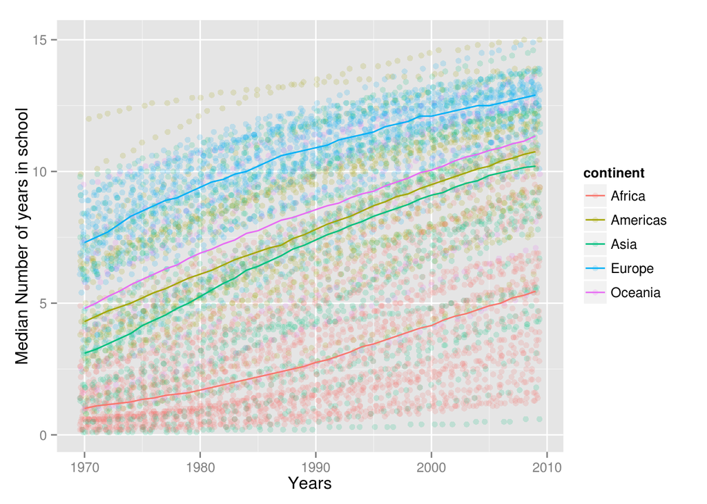

```r
ggplot(aes(x = 1969 + year.as.numeric, y = mean.num.years), data = gather.school) +
  geom_point(alpha = 1/6,position = position_jitter(h=0), aes(color = continent)) +
  geom_line(stat = 'summary', fun.y = median, data = subset(gather.school %>% group_by(continent)), aes(color = continent))+
  xlab("Years") +
  ylab("Median Number of years in school")
```

#### Values per region.

```r
gather.school %>%
  group_by(region) %>%
  summarise(mean = mean(mean.num.years), median = median(mean.num.years), n = n()) %>%
  arrange(desc(median))
```

```
## Source: local data frame [22 x 4]
##
##                       region      mean median   n
## 1           Northern America 13.160000  13.35  80
## 2            Northern Europe 11.407500  11.70 360
## 3             Eastern Europe 11.092750  11.40 400
## 4  Australia and New Zealand 11.110000  11.30  80
## 5             Western Europe 10.476786  10.70 280
## 6               Central Asia  9.945000  10.25 200
## 7                  Polynesia  9.792500  10.05  80
## 8               Eastern Asia  9.486000   9.75 200
## 9                  Caribbean  8.543750   9.05 320
## 10           Southern Europe  8.766591   9.00 440
## ..                       ...       ...    ... ...
```

Plot of the Medians:

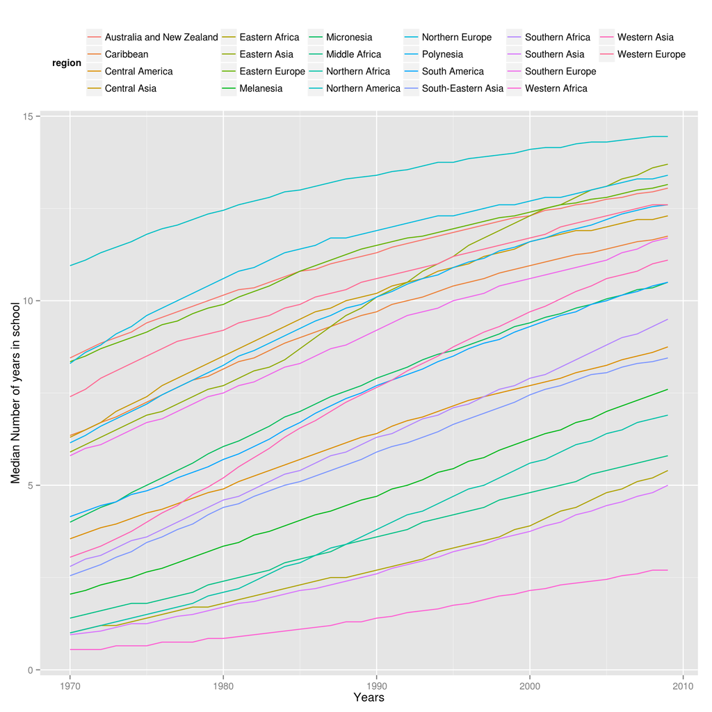

```r
ggplot(aes(x = 1969 + year.as.numeric, y = mean.num.years), data = gather.school) +
  geom_line(stat = 'summary', fun.y = median, aes(color = region)) +
  xlab("Years") +
  ylab("Median Number of years in school") +
  theme(legend.position = "top") +
  guides(color=guide_legend(nrow = 4))
```

## Conclusions

With this study we are able to observe:

1. The values for the mean years spent in school throughout the years.
2. The improvement and evolution of some countries.
3. The countries with the lowest values in 1970 were not able to improve their results in a significant way.
4. The continents relative position remains the same in 2009 as is was in 1970, with Europe having the highest median in mean years spent in school, and Africa with the lowest value.
5. The data contextualized by region gives us a more rich and detailed view, where we can see that regions have experienced increase in these values at very different rates.

Sara Carvalho 05-05-2015